# NHS Sussex POF Indicators Data Tool

West Sussex Public Health and Social Research Unit, 2025

[figure not shown]

# Overview - the State of Sussex

This interactive report shows the latest outcomes framework indicators for NHS and local authority organisations across Sussex.

There are currently **226** indicators in this report grouped into 12 domains. Some indicators have demographic breakdowns by age or sex; for example, life expectancy at birth is reported for males and females separately) and so will appear as multiple lines in the tables.

You can use the navigation panel on the left to navigate down this page to the table containing the domain specific indicators.

Some of these indicators are **CORE20Plus5** indicators and NHS Health Inequalities 2024 Statement (**HIState**) indicators. These are identified with in the domain tables throughout this report.

Data provided here are usually available for local authority geographies (East Sussex and West Sussex upper tier and Brighton and Hove unitary authorities, referred to as UTLAs) or for the equivalent Sub-ICB locations.

## Reading the tables

The tables in this report show one row per indicator with each area/organisation’s latest value, a comparison against England, a recent trend, and rankings among demographically similar peers and national ranks, displayed for a quick glance of the **State of Sussex**.

You can search for an indicator name in each table. For some indicators, there may be additional notes which users may find helpful when interpreting the values, particularly where there are one or more outliers of concern.

Where this is the case the indicator will have a purple note icon next to it; hover of this to find out more. I am an informative tooltip

An explainer table is given below and a table key ‘reading the icons’ is available on the bottom left of the page.

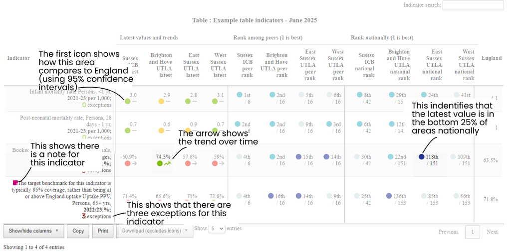

*An image showing how to read icons in an example table*

The first icon, a circle under the latest value, shows whether the latest value is statistically different compared to the England value for the same time period. A **green circle** () shows the value is significantly better than England, a **red circle** () shows significantly worse than the England value and a **yellow circle** () shows that the value is not statistically significantly different to England. In some cases, a higher or lower value is not considered good or bad. For these, we use a **dark green circle** () to show significantly higher values, and **light green circle** () to show lower values.

The second icon shows an arrow for the trend of the latest value, where data is available, with the direction and colour denoting improvement over time (**green arrow**, either or ), getting worse over time (**red arrow**, either or ) or with no change (**grey arrow**, ). A grey dash () denotes no comparison available. Again, where there is no polarity value (e.g. going up isn’t good or bad) the arrow is **purple**, either or ).

In some cases there are no data at all for either a trend or comparison or the latest value. This could be because of missing data, or a data quality issue meaning that the value has not been published. Where this is the case, the table will show a grey dash icon ().

For rankings, each area type is compared with demographically similar peers as well as areas across the whole of England. There is one icon next to the rank which is coloured **light blue** () if the area is among the top 25% of areas, and **dark blue** () if it is in the bottom 25% of areas (with **light grey** () showing it is ranked somewhere in the middle).

A table listing the peers for each area are given at the bottom of this report. Go to peer list

For ICBs, there are up to six peers, SICBLs are compared with up to 11 peers and UTLAs are compared with up to 16 peers. As at July 2025, there 42 ICBs, 106 SICBLs, and 153 UTLAs and our areas are ranked amongst these respective areas.

*In cases where two areas have the same value (tied values), these are both given the highest (closest to 1st/best) rank. The grouping of areas into quartiles ignores ties and so some areas with the same score may be placed in two different quartiles.*

## Outliers and indicators of concern

In this report, we talk about **‘outliers of concern’** as being any value which is either **significantly worse than the England value (denoted with a ), OR if the value is in the bottom quartile nationally (denoted by a )**.

In addition to using the term value of concern, we also detail **‘indicators of concern’**. These are indicators with at least one area/organisation that has a value of concern.

There are a few things to remember when interpreting these outliers/indicators of concern;

There are a total of 226 indicators. Of these, **73 are indicators of concern;** that is indicators with at least one area with an outlier value of concern. This is **32.3%** of indicators.

For five indicators, every area had an outlier value of concern. These were; the proportion of estimated eligible population offered an NHS Health Check, Cholesterol: QRISK >= 20% treated with LLT, Proportion of those with Atrial Fibrillation treated with anticoagulants, proportion of current smokers offered support/treatment, and the uptake of physical health checks among those diagnosed with Serious Mental Illness (SMI).

The table below shows the number of indicators in each domain, as well as the number of indicators with at least one outlier value of concern.

| Domain | Indicators | Indicators with at least one outlier of concern value | Percentage of indicators with at least one outlier of concern value |
| --- | --- | --- | --- |
| Overarching | 6 | 0 | 0% |
| Good Infant and Maternal Health | 22 | 3 | 13.6% |
| Strong Foundations for Health | 31 | 11 | 35.5% |
| Maintaining health and mobility | 15 | 4 | 26.7% |
| Tackling Childhood Long Term Conditions | 11 | 5 | 45.5% |
| Mental Health Support | 8 | 4 | 50% |
| Core Determinants | 10 | 2 | 20% |
| Increasing Burdens | 16 | 4 | 25% |
| Tackling Alcohol | 7 | 2 | 28.6% |
| Tackling major burdens | 57 | 18 | 31.6% |

[output cut: 4 more lines]

Use the check boxes below to show/hide indicators with at least one area which has an outlier of concern.

Toggle only indicators of concern

Indicator of concern

No data

Not an indicator of concern

# 00. Overarching indicators

Overarching indicators include life expectancy at birth, healthy life expectancy, and the social inequality gap in life expectancy across. All of these indicators are for UTLAs and the Sussex ICB footprint overall.

[interactive table not shown]

# 01. Good Infant and Maternal Health indicators

Good Infant and Maternal Health include infant mortality rates, maternity bookings, specialist perinatal measures and also baby weights and preterm births.

[interactive table not shown]

# 02. Strong Foundations for Health indicators

Strong Foundations for Health include readiness for school measures, uptake of childhood immunisations, healthy weight prevalence, special education needs and attainment scores and tooth extractions.

[interactive table not shown]

# 03. Tackling Childhood Long Term Conditions indicators

The majority of indicators are for the local authority geographies, with the exception of second-hand smoking status among patients with asthma aged 6-19 years which is available for the ICB and sub ICB locations. The sub ICB location values are given in a separate table.

[interactive table not shown]

# 04. Mental Health Support indicators

Mental Health Support indicators primarily focus on young people’s access to mental health services, children and young people with eating disorders, hospital admissions for self harm, and measures of transitions from children’s to adult’s services.

Some of these indicators are CORE20Plus5 indicators and NHS Health Inequalities 2024 Statement indicators. These are identified with **CORE20Plus5** and **HIState** labels in the tables.

[interactive table not shown]

# 05. Core Determinants indicators

The Core Determinants domain is the first indicator in the Working Age section of the Sussex Population Outcomes Framework. These domains represent wider determinants and increasing challenges for population health.

This includes the Local Health Index, measures of employment, homelessness, fuel poverty, air pollution, and active travel.

[interactive table not shown]

# 06. Increasing Burdens indicators

The increasing burdens domain focuses on obesity prevalence and management of diabetes among adults. Some of these indicators are NHS Health Inequalities 2024 Statement indicators. These are identified with **HIState** labels in the tables.

Data for amputations of minor and major limbs are available at Sub ICB location geographies and as such are given in a second table.

[interactive table not shown]

# 07. Tackling Alcohol indicators

This domain features admission episodes for alcohol specific conditions, and alcohol misuse treatment services.

[interactive table not shown]

# 08. Tackling major burdens indicators

The Tackling Major burdens of ill health and premature mortality is the biggest domain and is split into three sub domains; cardiovascular disease, respiratory disease, and cancer. For each of these condition subgroups there are measures for premature mortality, detection and diagnosis, access to services and stage of presentation.

Some of these indicators are CORE20Plus5 indicators and NHS Health Inequalities 2024 Statement indicators. These are identified with **CORE20Plus5** and **HIState** labels in the tables.

[interactive table not shown]

# 09. Improving Adult Mental Health and Wellbeing indicators

The Improving Adult Mental Health and Wellbeing indicators domain explores self-reported wellbeing, and a range of measures of health experiences of those with severe mental illness. It also includes drug related deaths and suicide rates, and rates of detentions under the Mental Health Act.

Some of these indicators are CORE20Plus5 indicators and NHS Health Inequalities 2024 Statement indicators. These are identified with **CORE20Plus5** and **HIState** labels in the tables.

[interactive table not shown]

# 10. Maintaining Health and Mobility indicators

The Maintaining Health and Mobility is part of the Active Ageing and Later Life section of the Sussex Population Outcomes Framework.

Indicators include adult physical activity and inactivity prevalence estimates, emergency hospital admissions due to falls, assessment and management of osteoporosis, and readmissions following hip replacement surgery.

[interactive table not shown]

# 11. Care and Support indicators

The Care and Support indicators include measures of self-reported quality of life, confidence, and feeling supported for managing long term conditions. It also includes social prescribing referral rates, diagnosis rates for dementia.

[interactive table not shown]

# 12. Inclusive Elective indicators

The final domain is inclusive elective. This explores measures around treatment waiting times, reducing did not attend rates, improving access to diagnostics services and measures of elective activity trends over time particularly looking at pre- and post- COVID-19 pandemic.

Some of these indicators are NHS Health Inequalities 2024 Statement indicators. These are identified with **HIState** labels in the tables.

[interactive table not shown]

## References and data sources

Office for Health Improvement & Disparities. Public Health Profiles. 2025 https://fingertips.phe.org.uk © Crown copyright 2025

Other data sources include: CYP Transformation Programme Dashboard, National Diabetes Audit (NDA) NHS England Digital, Model Hospital, Mental Health Act Statistics, Learning disability services monthly statistics from the Assuring Transformation dataset, Network Contract DES, CVDPREVENT, Young People with Type 2 Diabetes NHS England Digital, Mental Health Services Monthly Statistics, Cancer Waiting Times Database, NHS England: monthly RTT data collection, NHS England: DM01, collected via SDCS, CYP Elective Recovery Dashboard

A full list of data sources will be made available as a separate metadata file.

## Peer groups

Each area is compared with a areas that are demographically similar. This means that Brighton and Hove (UTLA) is compared with a different set of areas to East Sussex (UTLA). The table below shows which areas each of our geographies are compared to.

| Sussex ICB | Brighton and Hove UTLA | East Sussex UTLA | West Sussex UTLA | Brighton and Hove SubICB location | East Sussex SubICB location | West Sussex SubICB location |
| --- | --- | --- | --- | --- | --- | --- |
| NHS Hampshire and Isle of Wight Integrated Care Board - QRL | York | East Riding of Yorkshire | South Gloucestershire | Hampshire and Isle Of Wight ICB - 10R | Dorset ICB - 11J | Dorset ICB - 11J |
| NHS Humber and North Yorkshire Integrated Care Board - QOQ | Bristol | North Somerset | Cheshire East | South Yorkshire ICB - 03N | Somerset ICB - 11X | Cheshire and Merseyside ICB - 27D |
| NHS Kent and Medway Integrated Care Board - QKS | Plymouth | Cheshire East | Cheshire West and Chester | Mid and South Essex ICB - 07G | Herefordshire and Worcestershire ICB - 18C | Gloucestershire ICB - 11M |
| NHS Mid and South Essex Integrated Care Board - QH8 | Reading | Cheshire West and Chester | East Sussex | West Yorkshire ICB - 15F | Shropshire, Telford and Wrekin ICB - M2L0M | Bath and North East Somerset, Swindon and Wiltshire ICB - 92G |
| NHS Suffolk and North East Essex Integrated Care Board - QJG | Portsmouth | Wiltshire | Essex | North East and North Cumbria ICB - 13T | Suffolk and North East Essex ICB - 06L | Herefordshire and Worcestershire ICB - 18C |
| NHS Sussex Integrated Care Board - QNX | Southampton | Dorset | Gloucestershire | Greater Manchester ICB - 01G | Lincolnshire ICB - 71E | Hampshire and Isle Of Wight ICB - D9Y0V |
|  | Salford | Somerset UA | Hampshire | Lancashire and South Cumbria ICB - 01E | Humber and North Yorkshire ICB - 02Y | Surrey Heartlands ICB - 92A |
|  | Trafford | Sefton | Kent | Leicester, Leicestershire and Rutland ICB - 04C | Suffolk and North East Essex ICB - 07K | Sussex ICB - 97R |
|  | Liverpool | Devon | Lancashire | Bristol, North Somerset and South Gloucestershire ICB - 15C | Norfolk and Waveney ICB - 26A | Mid and South Essex ICB - 06Q |
|  | Newcastle upon Tyne | Essex | Norfolk | West Yorkshire ICB - X2C4Y | Humber and North Yorkshire ICB - 42D | Devon ICB - 15N |

[output cut: 5 more lines]